# Biostat 203B Homework 4

Due Mar 24 @ 11:59PM

Author

Sylvia Wang, 105118268

Load database libraries and the tidyverse frontend:

```r
suppressPackageStartupMessages(library(dplyr))
suppressPackageStartupMessages(library(tidyverse))
suppressPackageStartupMessages(library(tidymodels))
suppressPackageStartupMessages(library(lubridate))
suppressPackageStartupMessages(library(GGally))
suppressPackageStartupMessages(library(gtsummary))
```

## 1 Predicting 30-day mortality

Using the ICU cohort `icu_cohort.rds` you built in Homework 3, develop at least three analytic approaches for predicting the 30-day mortality of patients admitted to ICU using demographic information (gender, age, marital status, ethnicity), first lab measurements during ICU stay, and first vital measurements during ICU stay. For example, you can use (1) logistic regression with elastic net (lasso + ridge) penalty (e.g., glmnet or keras package), (2) random forest, (3) boosting, and (4) support vector machines, or (5) MLP neural network (keras package)

Data preparation: Create a reduced dataset containing only demographic information (gender, age, marital status, ethnicity), first lab measurements during ICU stay, first vital measurements during ICU stay, and thirty day mortality indicator. For lab and vital measurements, extreme outliers (those beyond the outer fence, i.e., +/-3*IQR) were reassigned as `NA`’s, because some obvious unrealistic values have been identified from the data (e.g. a negative heart rate or a heart rate of zero, etc.).

```r
icu_cohort <- readRDS("icu_cohort.rds")
icu_cohort_reduced <- icu_cohort %>%
  select("gender", "age_hadm", "marital_status", "ethnicity", "sodium",
         "chloride", "potassium", "bicarbonate", "hematocrit", "creatinine",
         "wbc_count", "glucose", "bp_systolic", "bp_mean", "resp_rate",
         "heart_rate", "temp", "thirty_day_mort")

vars <- c("sodium", "chloride", "potassium", "bicarbonate", "hematocrit",
          "creatinine", "wbc_count", "glucose", "bp_systolic", "bp_mean",
          "resp_rate", "heart_rate", "temp")
outlier_removed <- function(x){
    p25 <- quantile(x, probs = 0.25, na.rm=T)
    p75 <- quantile(x, probs = 0.75, na.rm=T)
    IQR <- p75 - p25
    x <- ifelse(x > p75 + 3 * IQR | x < p25 - 3 * IQR , NA, x)
}
lab_vital <- icu_cohort_reduced %>%
  select(all_of(vars)) %>%
  apply(2, outlier_removed)
icu_cohort_reduced[, colnames(lab_vital)] <- lab_vital
icu_cohort_reduced %>% tbl_summary(by = thirty_day_mort)
```

| **Characteristic** | **FALSE**, N = 47,642<sup>1</sup> | **TRUE**, N = 5,508<sup>1</sup> |
| --- | --- | --- |
| gender |  |  |
| F | 20,804 (44%) | 2,549 (46%) |
| M | 26,838 (56%) | 2,959 (54%) |
| age_hadm | 66 (53, 77) | 73 (61, 83) |
| marital_status |  |  |
| DIVORCED | 3,376 (7.7%) | 319 (7.2%) |
| MARRIED | 21,929 (50%) | 2,183 (49%) |
| SINGLE | 13,156 (30%) | 1,086 (24%) |
| WIDOWED | 5,603 (13%) | 867 (19%) |
| Unknown | 3,578 | 1,053 |
| ethnicity |  |  |
| AMERICAN INDIAN/ALASKA NATIVE | 87 (0.2%) | 7 (0.1%) |
| ASIAN | 1,395 (2.9%) | 169 (3.1%) |
| BLACK/AFRICAN AMERICAN | 4,473 (9.4%) | 401 (7.3%) |
| HISPANIC/LATINO | 1,703 (3.6%) | 124 (2.3%) |
| OTHER | 2,312 (4.9%) | 225 (4.1%) |
| UNABLE TO OBTAIN | 631 (1.3%) | 128 (2.3%) |
| UNKNOWN | 4,646 (9.8%) | 1,181 (21%) |
| WHITE | 32,395 (68%) | 3,273 (59%) |
| sodium | 137.0 (134.0, 139.0) | 136.0 (132.0, 139.0) |
| Unknown | 1,686 | 534 |
| chloride | 102.0 (99.0, 105.0) | 100.0 (95.0, 105.0) |
| Unknown | 1,432 | 461 |
| potassium | 3.70 (3.40, 4.10) | 3.60 (3.20, 4.10) |
| Unknown | 1,340 | 475 |
| bicarbonate | 22.0 (20.0, 24.0) | 18.0 (14.0, 22.0) |
| Unknown | 1,391 | 453 |
| hematocrit | 30 (25, 35) | 27 (22, 32) |
| Unknown | 1,392 | 449 |
| creatinine | 0.80 (0.60, 1.00) | 1.00 (0.70, 1.40) |
| Unknown | 3,435 | 1,010 |
| wbc_count | 8.4 (6.3, 11.0) | 9.1 (6.0, 12.8) |
| Unknown | 1,850 | 689 |
| glucose | 103 (89, 121) | 100 (80, 124) |
| Unknown | 2,052 | 680 |
| bp_systolic | 93 (83, 104) | 80 (67, 92) |
| Unknown | 494 | 337 |
| bp_mean | 59 (52, 68) | 51 (41, 60) |
| Unknown | 500 | 292 |
| resp_rate | 11.0 (9.0, 13.0) | 9.0 (0.0, 13.0) |
| Unknown | 59 | 20 |
| heart_rate | 65 (57, 74) | 65 (54, 78) |
| Unknown | 133 | 1,224 |
| temp | 97.50 (97.00, 97.90) | 97.30 (96.30, 97.70) |
| Unknown | 1,167 | 861 |

<sup>1</sup> n (%); Median (IQR)

### 1.1 Partition data into 50% training set and 50% test set. Stratify partitioning according the 30-day mortality status.

```r
icu_cohort_reduced$thirty_day_mort <-
  as.factor(icu_cohort_reduced$thirty_day_mort)

set.seed(203)
data_split <- initial_split(
  icu_cohort_reduced,
  strata = "thirty_day_mort",
  prop = 0.5)
data_split
```

```
<Training/Testing/Total>
<26575/26575/53150>
```

```r
train <- training(data_split)
dim(train)
```

```
[1] 26575    18
```

```r
test <- testing(data_split)
dim(test)
```

```
[1] 26575    18
```

### 1.2 Train and tune the models using the training set.

#### 1.2.1 Method 1: Logistic regression with elastic net regularization

```r
# Recipe and Preprocessing:
sapply(icu_cohort_reduced, class)
```

```
         gender        age_hadm  marital_status       ethnicity          sodium
    "character"       "integer"     "character"     "character"       "numeric"
       chloride       potassium     bicarbonate      hematocrit      creatinine
      "numeric"       "numeric"       "numeric"       "numeric"       "numeric"
      wbc_count         glucose     bp_systolic         bp_mean       resp_rate
      "numeric"       "numeric"       "numeric"       "numeric"       "numeric"
     heart_rate            temp thirty_day_mort
      "numeric"       "numeric"        "factor"
```

```r
logit_recipe <- recipe(thirty_day_mort ~ ., data = train) %>%
  step_impute_mean(sodium) %>%
  step_impute_mean(chloride) %>%
  step_impute_mean(potassium) %>%
  step_impute_mean(bicarbonate) %>%
  step_impute_mean(hematocrit) %>%
  step_impute_mean(creatinine) %>%
  step_impute_mean(wbc_count) %>%
  step_impute_mean(glucose) %>%
  step_impute_mean(bp_systolic) %>%
  step_impute_mean(bp_mean) %>%
  step_impute_mean(resp_rate) %>%
  step_impute_mean(heart_rate) %>%
  step_impute_mean(temp) %>%
  step_impute_mode(marital_status) %>%
  step_dummy(all_nominal_predictors()) %>%
  step_zv(all_numeric_predictors()) %>%
  step_normalize(all_numeric_predictors()) %>%
  prep(training = train, retain = TRUE)
logit_recipe
```

```
Recipe

Inputs:

      role #variables
   outcome          1
 predictor         17

Training data contained 26575 data points and 6514 incomplete rows.

Operations:

Mean imputation for sodium [trained]
Mean imputation for chloride [trained]
Mean imputation for potassium [trained]
Mean imputation for bicarbonate [trained]
Mean imputation for hematocrit [trained]
Mean imputation for creatinine [trained]
Mean imputation for wbc_count [trained]
Mean imputation for glucose [trained]
Mean imputation for bp_systolic [trained]
Mean imputation for bp_mean [trained]
Mean imputation for resp_rate [trained]
Mean imputation for heart_rate [trained]
Mean imputation for temp [trained]
Mode imputation for marital_status [trained]
Dummy variables from gender, marital_status, ethnicity [trained]
Zero variance filter removed <none> [trained]
Centering and scaling for age_hadm, sodium, chloride, potassium, bicarbon... [trained]
```

```r
# Create model:
logit_mod <- logistic_reg(penalty = tune(), mixture = tune()) %>%
  set_engine("glmnet", standardize = FALSE)
logit_mod
```

```
Logistic Regression Model Specification (classification)

Main Arguments:
  penalty = tune()
  mixture = tune()

Engine-Specific Arguments:
  standardize = FALSE

Computational engine: glmnet
```

```r
# Bundle the recipe and model:
logit_wf <- workflow() %>%
  add_recipe(logit_recipe) %>%
  add_model(logit_mod)
logit_wf
```

```
══ Workflow ════════════════════════════════════════════════════════════════════
Preprocessor: Recipe
Model: logistic_reg()

── Preprocessor ────────────────────────────────────────────────────────────────
17 Recipe Steps

• step_impute_mean()
• step_impute_mean()
• step_impute_mean()
• step_impute_mean()
• step_impute_mean()
• step_impute_mean()
• step_impute_mean()
• step_impute_mean()
• step_impute_mean()
• step_impute_mean()
• ...
• and 7 more steps.

── Model ───────────────────────────────────────────────────────────────────────
Logistic Regression Model Specification (classification)

Main Arguments:
  penalty = tune()
  mixture = tune()

Engine-Specific Arguments:
  standardize = FALSE

Computational engine: glmnet
```

```r
# Tuning grid:
param_grid <- grid_regular(
  penalty(range = c(-6, 3)),
  mixture(),
  levels = c(100, 5))

# Cross validation:
set.seed(203)
folds <- vfold_cv(train, v = 5)
folds
```

```
#  5-fold cross-validation
# A tibble: 5 × 2
  splits               id
  <list>               <chr>
1 <split [21260/5315]> Fold1
2 <split [21260/5315]> Fold2
3 <split [21260/5315]> Fold3
4 <split [21260/5315]> Fold4
5 <split [21260/5315]> Fold5
```

```r
# Fit cross validation:
system.time({
logit_fit <- logit_wf %>%
  tune_grid(
    resamples = folds,
    grid = param_grid,
    metrics = metric_set(roc_auc, accuracy)
    )
})
```

```
   user  system elapsed
 78.670  15.748  95.049
```

```r
logit_fit
```

```
# Tuning results
# 5-fold cross-validation
# A tibble: 5 × 4
  splits               id    .metrics             .notes
  <list>               <chr> <list>               <list>
1 <split [21260/5315]> Fold1 <tibble [1,000 × 6]> <tibble [0 × 3]>
2 <split [21260/5315]> Fold2 <tibble [1,000 × 6]> <tibble [0 × 3]>
3 <split [21260/5315]> Fold3 <tibble [1,000 × 6]> <tibble [0 × 3]>
4 <split [21260/5315]> Fold4 <tibble [1,000 × 6]> <tibble [0 × 3]>
5 <split [21260/5315]> Fold5 <tibble [1,000 × 6]> <tibble [0 × 3]>
```

```
# A tibble: 1,000 × 8
      penalty mixture .metric  .estimator  mean     n std_err
        <dbl>   <dbl> <chr>    <chr>      <dbl> <int>   <dbl>
 1 0.000001         0 accuracy binary     0.906     5 0.00121
 2 0.000001         0 roc_auc  binary     0.808     5 0.00390
 3 0.00000123       0 accuracy binary     0.906     5 0.00121
 4 0.00000123       0 roc_auc  binary     0.808     5 0.00390
 5 0.00000152       0 accuracy binary     0.906     5 0.00121
 6 0.00000152       0 roc_auc  binary     0.808     5 0.00390
 7 0.00000187       0 accuracy binary     0.906     5 0.00121
 8 0.00000187       0 roc_auc  binary     0.808     5 0.00390
 9 0.00000231       0 accuracy binary     0.906     5 0.00121
10 0.00000231       0 roc_auc  binary     0.808     5 0.00390
   .config
   <chr>
 1 Preprocessor1_Model001
 2 Preprocessor1_Model001
 3 Preprocessor1_Model002
 4 Preprocessor1_Model002
 5 Preprocessor1_Model003
 6 Preprocessor1_Model003
 7 Preprocessor1_Model004
 8 Preprocessor1_Model004
 9 Preprocessor1_Model005
10 Preprocessor1_Model005
# … with 990 more rows
```

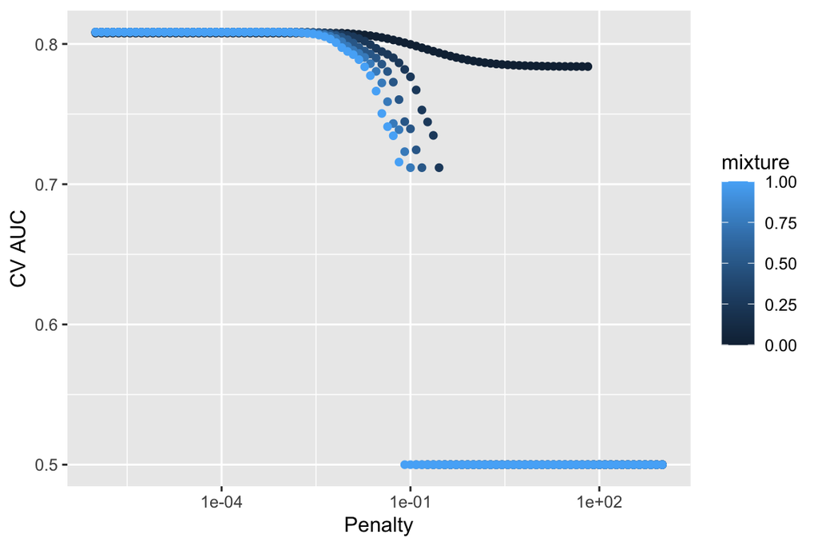

```r
# Visualize CV results:
logit_fit %>%
  collect_metrics() %>%
  print(width = Inf) %>%
  filter(.metric == "roc_auc") %>%
  ggplot(mapping = aes(x = penalty, y = mean, color = mixture)) +
  geom_point() +
  labs(x = "Penalty", y = "CV AUC") +
  scale_x_log10()
```

```r
# Show the top 5 models:
logit_fit %>% show_best("roc_auc")
```

```
# A tibble: 5 × 8
   penalty mixture .metric .estimator  mean     n std_err .config
     <dbl>   <dbl> <chr>   <chr>      <dbl> <int>   <dbl> <chr>
1 0.000351       1 roc_auc binary     0.809     5 0.00404 Preprocessor1_Model429
2 0.000534       1 roc_auc binary     0.809     5 0.00410 Preprocessor1_Model431
3 0.000433       1 roc_auc binary     0.809     5 0.00407 Preprocessor1_Model430
4 0.000658       1 roc_auc binary     0.809     5 0.00412 Preprocessor1_Model432
5 0.000285       1 roc_auc binary     0.809     5 0.00403 Preprocessor1_Model428
```

```r
# Select the best model:
best_logit <- logit_fit %>% select_best("roc_auc")
best_logit
```

```
# A tibble: 1 × 3
   penalty mixture .config
     <dbl>   <dbl> <chr>
1 0.000351       1 Preprocessor1_Model429
```

```r
# Finalize model:
# Final workflow:
final_wf <- logit_wf %>% finalize_workflow(best_logit)
final_wf
```

```
══ Workflow ════════════════════════════════════════════════════════════════════
Preprocessor: Recipe
Model: logistic_reg()

── Preprocessor ────────────────────────────────────────────────────────────────
17 Recipe Steps

• step_impute_mean()
• step_impute_mean()
• step_impute_mean()
• step_impute_mean()
• step_impute_mean()
• step_impute_mean()
• step_impute_mean()
• step_impute_mean()
• step_impute_mean()
• step_impute_mean()
• ...
• and 7 more steps.

── Model ───────────────────────────────────────────────────────────────────────
Logistic Regression Model Specification (classification)

Main Arguments:
  penalty = 0.000351119173421513
  mixture = 1

Engine-Specific Arguments:
  standardize = FALSE

Computational engine: glmnet
```

```r
# Fit the whole training set and predict the test cases:
final_fit <- final_wf %>% last_fit(data_split)
final_fit
```

```
# Resampling results
# Manual resampling
# A tibble: 1 × 6
  splits                id               .metrics .notes   .predict…¹ .workflow
  <list>                <chr>            <list>   <list>   <list>     <list>
1 <split [26575/26575]> train/test split <tibble> <tibble> <tibble>   <workflow>
# … with abbreviated variable name ¹.predictions
```

```r
# Test metrics:
final_fit %>% collect_metrics()
```

```
# A tibble: 2 × 4
  .metric  .estimator .estimate .config
  <chr>    <chr>          <dbl> <chr>
1 accuracy binary         0.908 Preprocessor1_Model1
2 roc_auc  binary         0.807 Preprocessor1_Model1
```

#### 1.2.2 Method 2: Random forest

```r
# Recipe and preprocessing:
rf_recipe <- recipe(thirty_day_mort ~ ., data = train) %>%
  step_impute_mean(sodium) %>%
  step_impute_mean(chloride) %>%
  step_impute_mean(potassium) %>%
  step_impute_mean(bicarbonate) %>%
  step_impute_mean(hematocrit) %>%
  step_impute_mean(creatinine) %>%
  step_impute_mean(wbc_count) %>%
  step_impute_mean(glucose) %>%
  step_impute_mean(bp_systolic) %>%
  step_impute_mean(bp_mean) %>%
  step_impute_mean(resp_rate) %>%
  step_impute_mean(heart_rate) %>%
  step_impute_mean(temp) %>%
  step_impute_mode(marital_status) %>%
  step_zv(all_numeric_predictors()) %>%
  prep(training = train, retain = TRUE)
rf_recipe
```

```
Recipe

Inputs:

      role #variables
   outcome          1
 predictor         17

Training data contained 26575 data points and 6514 incomplete rows.

Operations:

Mean imputation for sodium [trained]
Mean imputation for chloride [trained]
Mean imputation for potassium [trained]
Mean imputation for bicarbonate [trained]
Mean imputation for hematocrit [trained]
Mean imputation for creatinine [trained]
Mean imputation for wbc_count [trained]
Mean imputation for glucose [trained]
Mean imputation for bp_systolic [trained]
Mean imputation for bp_mean [trained]
Mean imputation for resp_rate [trained]
Mean imputation for heart_rate [trained]
Mean imputation for temp [trained]
Mode imputation for marital_status [trained]
Zero variance filter removed <none> [trained]
```

```r
# Create model:
rf_mod <- rand_forest(
  mode = "classification",
  mtry = tune(),
  trees = tune()) %>%
  set_engine("ranger")
rf_mod
```

```
Random Forest Model Specification (classification)

Main Arguments:
  mtry = tune()
  trees = tune()

Computational engine: ranger
```

```r
# Create workflow:
rf_wf <- workflow() %>%
  add_recipe(rf_recipe) %>%
  add_model(rf_mod)
rf_wf
```

```
══ Workflow ════════════════════════════════════════════════════════════════════
Preprocessor: Recipe
Model: rand_forest()

── Preprocessor ────────────────────────────────────────────────────────────────
15 Recipe Steps

• step_impute_mean()
• step_impute_mean()
• step_impute_mean()
• step_impute_mean()
• step_impute_mean()
• step_impute_mean()
• step_impute_mean()
• step_impute_mean()
• step_impute_mean()
• step_impute_mean()
• ...
• and 5 more steps.

── Model ───────────────────────────────────────────────────────────────────────
Random Forest Model Specification (classification)

Main Arguments:
  mtry = tune()
  trees = tune()

Computational engine: ranger
```

```r
# Tuning grid:
param_grid_rf <- grid_regular(
  trees(range = c(100L, 300L)),
  mtry(range = c(1L, 5L)),
  levels = c(3, 5)
  )
param_grid_rf
```

```
# A tibble: 15 × 2
   trees  mtry
   <int> <int>
 1   100     1
 2   200     1
 3   300     1
 4   100     2
 5   200     2
 6   300     2
 7   100     3
 8   200     3
 9   300     3
10   100     4
11   200     4
12   300     4
13   100     5
14   200     5
15   300     5
```

```r
# Cross validation:
folds # created in method 1
```

```
#  5-fold cross-validation
# A tibble: 5 × 2
  splits               id
  <list>               <chr>
1 <split [21260/5315]> Fold1
2 <split [21260/5315]> Fold2
3 <split [21260/5315]> Fold3
4 <split [21260/5315]> Fold4
5 <split [21260/5315]> Fold5
```

```r
# Fit cross validation:
system.time({
rf_fit <- rf_wf %>%
  tune_grid(
    resamples = folds,
    grid = param_grid_rf,
    metrics = metric_set(roc_auc, accuracy)
    )
})
```

```
   user  system elapsed
327.457   7.929 278.324
```

```r
rf_fit
```

```
# Tuning results
# 5-fold cross-validation
# A tibble: 5 × 4
  splits               id    .metrics          .notes
  <list>               <chr> <list>            <list>
1 <split [21260/5315]> Fold1 <tibble [30 × 6]> <tibble [0 × 3]>
2 <split [21260/5315]> Fold2 <tibble [30 × 6]> <tibble [0 × 3]>
3 <split [21260/5315]> Fold3 <tibble [30 × 6]> <tibble [0 × 3]>
4 <split [21260/5315]> Fold4 <tibble [30 × 6]> <tibble [0 × 3]>
5 <split [21260/5315]> Fold5 <tibble [30 × 6]> <tibble [0 × 3]>
```

```
# A tibble: 30 × 8
    mtry trees .metric  .estimator  mean     n  std_err .config
   <int> <int> <chr>    <chr>      <dbl> <int>    <dbl> <chr>
 1     1   100 accuracy binary     0.907     5 0.000892 Preprocessor1_Model01
 2     1   100 roc_auc  binary     0.869     5 0.00381  Preprocessor1_Model01
 3     1   200 accuracy binary     0.907     5 0.00117  Preprocessor1_Model02
 4     1   200 roc_auc  binary     0.872     5 0.00368  Preprocessor1_Model02
 5     1   300 accuracy binary     0.907     5 0.00126  Preprocessor1_Model03
 6     1   300 roc_auc  binary     0.874     5 0.00382  Preprocessor1_Model03
 7     2   100 accuracy binary     0.919     5 0.000810 Preprocessor1_Model04
 8     2   100 roc_auc  binary     0.875     5 0.00397  Preprocessor1_Model04
 9     2   200 accuracy binary     0.919     5 0.000750 Preprocessor1_Model05
10     2   200 roc_auc  binary     0.878     5 0.00407  Preprocessor1_Model05
# … with 20 more rows
```

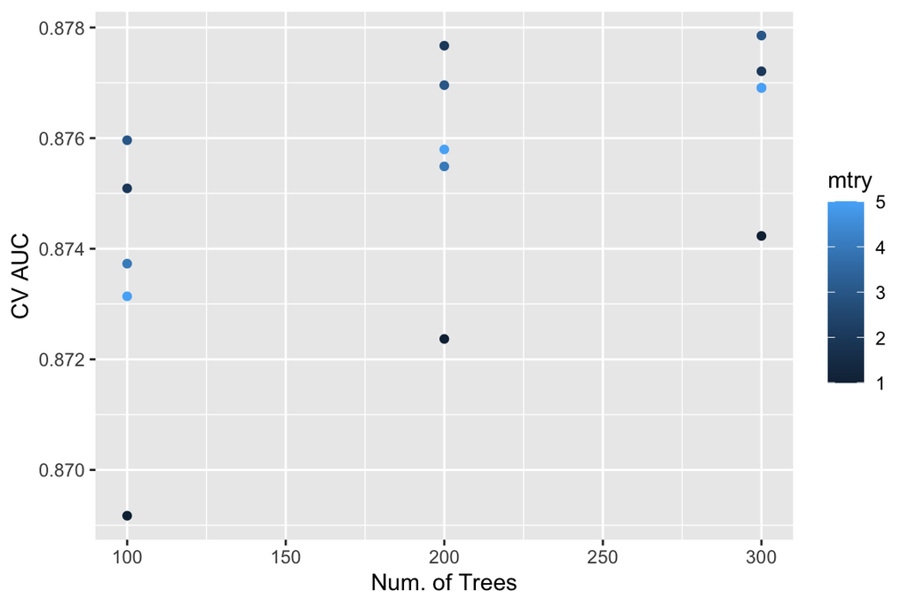

```r
# Visualize CV results:
rf_fit %>%
  collect_metrics() %>%
  print(width = Inf) %>%
  filter(.metric == "roc_auc") %>%
  ggplot(mapping = aes(x = trees, y = mean, color = mtry)) +
  geom_point() +
  labs(x = "Num. of Trees", y = "CV AUC")
```

```r
# Show the top 5 models:
rf_fit %>% show_best("roc_auc")
```

```
# A tibble: 5 × 8
   mtry trees .metric .estimator  mean     n std_err .config
  <int> <int> <chr>   <chr>      <dbl> <int>   <dbl> <chr>
1     3   300 roc_auc binary     0.878     5 0.00402 Preprocessor1_Model09
2     2   200 roc_auc binary     0.878     5 0.00407 Preprocessor1_Model05
3     2   300 roc_auc binary     0.877     5 0.00378 Preprocessor1_Model06
4     3   200 roc_auc binary     0.877     5 0.00411 Preprocessor1_Model08
5     5   300 roc_auc binary     0.877     5 0.00403 Preprocessor1_Model15
```

```r
# Select the best model:
best_rf <- rf_fit %>%
  select_best("roc_auc")
best_rf
```

```
# A tibble: 1 × 3
   mtry trees .config
  <int> <int> <chr>
1     3   300 Preprocessor1_Model09
```

```r
# Finalize the model:
# Final workflow:
final_wf_rf <- rf_wf %>%
  finalize_workflow(best_rf)
final_wf_rf
```

```
══ Workflow ════════════════════════════════════════════════════════════════════
Preprocessor: Recipe
Model: rand_forest()

── Preprocessor ────────────────────────────────────────────────────────────────
15 Recipe Steps

• step_impute_mean()
• step_impute_mean()
• step_impute_mean()
• step_impute_mean()
• step_impute_mean()
• step_impute_mean()
• step_impute_mean()
• step_impute_mean()
• step_impute_mean()
• step_impute_mean()
• ...
• and 5 more steps.

── Model ───────────────────────────────────────────────────────────────────────
Random Forest Model Specification (classification)

Main Arguments:
  mtry = 3
  trees = 300

Computational engine: ranger
```

```r
# Fit the whole training set and predict the test cases
final_fit_rf <- final_wf_rf %>%
  last_fit(data_split)
final_fit_rf
```

```
# Resampling results
# Manual resampling
# A tibble: 1 × 6
  splits                id               .metrics .notes   .predict…¹ .workflow
  <list>                <chr>            <list>   <list>   <list>     <list>
1 <split [26575/26575]> train/test split <tibble> <tibble> <tibble>   <workflow>
# … with abbreviated variable name ¹.predictions
```

```r
# Test metrics
final_fit_rf %>% collect_metrics()
```

```
# A tibble: 2 × 4
  .metric  .estimator .estimate .config
  <chr>    <chr>          <dbl> <chr>
1 accuracy binary         0.924 Preprocessor1_Model1
2 roc_auc  binary         0.881 Preprocessor1_Model1
```

#### 1.2.3 Method 3: Extreme gradient boosting (XGBoost)

```r
# Recipe and preprocessing:
gb_recipe <- recipe(thirty_day_mort ~ ., data = train) %>%
  step_impute_mean(sodium) %>%
  step_impute_mean(chloride) %>%
  step_impute_mean(potassium) %>%
  step_impute_mean(bicarbonate) %>%
  step_impute_mean(hematocrit) %>%
  step_impute_mean(creatinine) %>%
  step_impute_mean(wbc_count) %>%
  step_impute_mean(glucose) %>%
  step_impute_mean(bp_systolic) %>%
  step_impute_mean(bp_mean) %>%
  step_impute_mean(resp_rate) %>%
  step_impute_mean(heart_rate) %>%
  step_impute_mean(temp) %>%
  step_impute_mode(marital_status) %>%
  step_dummy(all_nominal_predictors()) %>%
  step_zv(all_numeric_predictors()) %>%
  prep(training = train, retain = TRUE)
gb_recipe
```

```
Recipe

Inputs:

      role #variables
   outcome          1
 predictor         17

Training data contained 26575 data points and 6514 incomplete rows.

Operations:

Mean imputation for sodium [trained]
Mean imputation for chloride [trained]
Mean imputation for potassium [trained]
Mean imputation for bicarbonate [trained]
Mean imputation for hematocrit [trained]
Mean imputation for creatinine [trained]
Mean imputation for wbc_count [trained]
Mean imputation for glucose [trained]
Mean imputation for bp_systolic [trained]
Mean imputation for bp_mean [trained]
Mean imputation for resp_rate [trained]
Mean imputation for heart_rate [trained]
Mean imputation for temp [trained]
Mode imputation for marital_status [trained]
Dummy variables from gender, marital_status, ethnicity [trained]
Zero variance filter removed <none> [trained]
```

```r
# Create model:
gb_mod <- boost_tree(
    mode = "classification",
    trees = 1000,
    tree_depth = tune(),
    learn_rate = tune()) %>%
  set_engine("xgboost")
gb_mod
```

```
Boosted Tree Model Specification (classification)

Main Arguments:
  trees = 1000
  tree_depth = tune()
  learn_rate = tune()

Computational engine: xgboost
```

```r
# Create workflow:
gb_wf <- workflow() %>%
  add_recipe(gb_recipe) %>%
  add_model(gb_mod)
gb_wf
```

```
══ Workflow ════════════════════════════════════════════════════════════════════
Preprocessor: Recipe
Model: boost_tree()

── Preprocessor ────────────────────────────────────────────────────────────────
16 Recipe Steps

• step_impute_mean()
• step_impute_mean()
• step_impute_mean()
• step_impute_mean()
• step_impute_mean()
• step_impute_mean()
• step_impute_mean()
• step_impute_mean()
• step_impute_mean()
• step_impute_mean()
• ...
• and 6 more steps.

── Model ───────────────────────────────────────────────────────────────────────
Boosted Tree Model Specification (classification)

Main Arguments:
  trees = 1000
  tree_depth = tune()
  learn_rate = tune()

Computational engine: xgboost
```

```r
# Tuning grid:
param_grid_gb <- grid_regular(
  tree_depth(range = c(1L, 3L)),
  learn_rate(range = c(-5, 2), trans = log10_trans()),
  levels = c(3, 10))
param_grid_gb
```

```
# A tibble: 30 × 2
   tree_depth learn_rate
        <int>      <dbl>
 1          1  0.00001
 2          2  0.00001
 3          3  0.00001
 4          1  0.0000599
 5          2  0.0000599
 6          3  0.0000599
 7          1  0.000359
 8          2  0.000359
 9          3  0.000359
10          1  0.00215
# … with 20 more rows
```

```r
# Cross validation:
folds # created in method 1
```

```
#  5-fold cross-validation
# A tibble: 5 × 2
  splits               id
  <list>               <chr>
1 <split [21260/5315]> Fold1
2 <split [21260/5315]> Fold2
3 <split [21260/5315]> Fold3
4 <split [21260/5315]> Fold4
5 <split [21260/5315]> Fold5
```

```r
# Fit cross validation:
gb_fit <- gb_wf %>%
  tune_grid(
    resamples = folds,
    grid = param_grid_gb,
    metrics = metric_set(roc_auc, accuracy))
gb_fit
```

```
# Tuning results
# 5-fold cross-validation
# A tibble: 5 × 4
  splits               id    .metrics          .notes
  <list>               <chr> <list>            <list>
1 <split [21260/5315]> Fold1 <tibble [60 × 6]> <tibble [0 × 3]>
2 <split [21260/5315]> Fold2 <tibble [60 × 6]> <tibble [0 × 3]>
3 <split [21260/5315]> Fold3 <tibble [60 × 6]> <tibble [0 × 3]>
4 <split [21260/5315]> Fold4 <tibble [60 × 6]> <tibble [0 × 3]>
5 <split [21260/5315]> Fold5 <tibble [60 × 6]> <tibble [0 × 3]>
```

```
# A tibble: 60 × 8
   tree_depth learn_rate .metric  .estimator  mean     n  std_err
        <int>      <dbl> <chr>    <chr>      <dbl> <int>    <dbl>
 1          1  0.00001   accuracy binary     0.896     5 0.000934
 2          1  0.00001   roc_auc  binary     0.640     5 0.00529
 3          2  0.00001   accuracy binary     0.901     5 0.000788
 4          2  0.00001   roc_auc  binary     0.711     5 0.00428
 5          3  0.00001   accuracy binary     0.901     5 0.000763
 6          3  0.00001   roc_auc  binary     0.744     5 0.00760
 7          1  0.0000599 accuracy binary     0.896     5 0.000934
 8          1  0.0000599 roc_auc  binary     0.640     5 0.00529
 9          2  0.0000599 accuracy binary     0.901     5 0.000788
10          2  0.0000599 roc_auc  binary     0.730     5 0.00533
   .config
   <chr>
 1 Preprocessor1_Model01
 2 Preprocessor1_Model01
 3 Preprocessor1_Model02
 4 Preprocessor1_Model02
 5 Preprocessor1_Model03
 6 Preprocessor1_Model03
 7 Preprocessor1_Model04
 8 Preprocessor1_Model04
 9 Preprocessor1_Model05
10 Preprocessor1_Model05
# … with 50 more rows
```

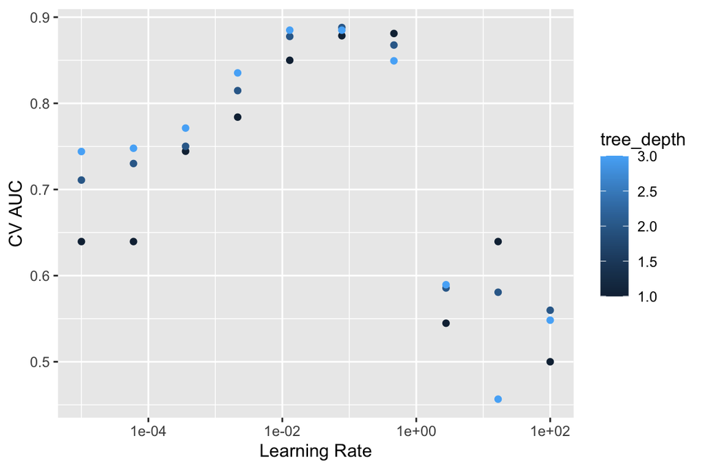

```r
# Visualize CV results:
gb_fit %>%
  collect_metrics() %>%
  print(width = Inf) %>%
  filter(.metric == "roc_auc") %>%
  ggplot(mapping = aes(x = learn_rate, y = mean, color = tree_depth)) +
  geom_point() +
  labs(x = "Learning Rate", y = "CV AUC") +
  scale_x_log10()
```

```r
# Show the top 5 models:
gb_fit %>% show_best("roc_auc")
```

```
# A tibble: 5 × 8
  tree_depth learn_rate .metric .estimator  mean     n std_err .config
       <int>      <dbl> <chr>   <chr>      <dbl> <int>   <dbl> <chr>
1          2     0.0774 roc_auc binary     0.888     5 0.00351 Preprocessor1_Mo…
2          3     0.0129 roc_auc binary     0.885     5 0.00301 Preprocessor1_Mo…
3          3     0.0774 roc_auc binary     0.885     5 0.00378 Preprocessor1_Mo…
4          1     0.464  roc_auc binary     0.881     5 0.00348 Preprocessor1_Mo…
5          1     0.0774 roc_auc binary     0.878     5 0.00375 Preprocessor1_Mo…
```

```r
# Select the best model:
best_gb <- gb_fit %>%
  select_best("roc_auc")
best_gb
```

```
# A tibble: 1 × 3
  tree_depth learn_rate .config
       <int>      <dbl> <chr>
1          2     0.0774 Preprocessor1_Model17
```

```r
# Finalize the model:
# Final workflow:
final_wf_gb <- gb_wf %>%
  finalize_workflow(best_gb)
final_wf_gb
```

```
══ Workflow ════════════════════════════════════════════════════════════════════
Preprocessor: Recipe
Model: boost_tree()

── Preprocessor ────────────────────────────────────────────────────────────────
16 Recipe Steps

• step_impute_mean()
• step_impute_mean()
• step_impute_mean()
• step_impute_mean()
• step_impute_mean()
• step_impute_mean()
• step_impute_mean()
• step_impute_mean()
• step_impute_mean()
• step_impute_mean()
• ...
• and 6 more steps.

── Model ───────────────────────────────────────────────────────────────────────
Boosted Tree Model Specification (classification)

Main Arguments:
  trees = 1000
  tree_depth = 2
  learn_rate = 0.0774263682681127

Computational engine: xgboost
```

```r
# Fit the whole training set and predict the test cases
final_fit_gb <- final_wf_gb %>%
  last_fit(data_split)
final_fit_gb
```

```
# Resampling results
# Manual resampling
# A tibble: 1 × 6
  splits                id               .metrics .notes   .predict…¹ .workflow
  <list>                <chr>            <list>   <list>   <list>     <list>
1 <split [26575/26575]> train/test split <tibble> <tibble> <tibble>   <workflow>
# … with abbreviated variable name ¹.predictions
```

```r
# Test metrics
final_fit_gb %>% collect_metrics()
```

```
# A tibble: 2 × 4
  .metric  .estimator .estimate .config
  <chr>    <chr>          <dbl> <chr>
1 accuracy binary         0.932 Preprocessor1_Model1
2 roc_auc  binary         0.891 Preprocessor1_Model1
```

#### 1.2.4 Method 4: Support vector machines (SVM) with radial basis function (RBF) Kernel (I did not finish the step fitting the workflow to the CV due to extremely long running time)

```r
# Recipe and preprocessing:
svm_recipe <- recipe(thirty_day_mort ~ ., data = train) %>%
  step_impute_mean(sodium) %>%
  step_impute_mean(chloride) %>%
  step_impute_mean(potassium) %>%
  step_impute_mean(bicarbonate) %>%
  step_impute_mean(hematocrit) %>%
  step_impute_mean(creatinine) %>%
  step_impute_mean(wbc_count) %>%
  step_impute_mean(glucose) %>%
  step_impute_mean(bp_systolic) %>%
  step_impute_mean(bp_mean) %>%
  step_impute_mean(resp_rate) %>%
  step_impute_mean(heart_rate) %>%
  step_impute_mean(temp) %>%
  step_impute_mode(marital_status) %>%
  step_dummy(all_nominal_predictors()) %>%
  step_zv(all_numeric_predictors()) %>%
  prep(training = train, retain = TRUE)
svm_recipe
```

```
Recipe

Inputs:

      role #variables
   outcome          1
 predictor         17

Training data contained 26575 data points and 6514 incomplete rows.

Operations:

Mean imputation for sodium [trained]
Mean imputation for chloride [trained]
Mean imputation for potassium [trained]
Mean imputation for bicarbonate [trained]
Mean imputation for hematocrit [trained]
Mean imputation for creatinine [trained]
Mean imputation for wbc_count [trained]
Mean imputation for glucose [trained]
Mean imputation for bp_systolic [trained]
Mean imputation for bp_mean [trained]
Mean imputation for resp_rate [trained]
Mean imputation for heart_rate [trained]
Mean imputation for temp [trained]
Mode imputation for marital_status [trained]
Dummy variables from gender, marital_status, ethnicity [trained]
Zero variance filter removed <none> [trained]
```

```r
# Create model:
svm_mod <- svm_rbf(
    mode = "classification",
    cost = tune(),
    rbf_sigma = tune()) %>%
  set_engine("kernlab")
svm_mod
```

```
Radial Basis Function Support Vector Machine Model Specification (classification)

Main Arguments:
  cost = tune()
  rbf_sigma = tune()

Computational engine: kernlab
```

```r
# Create workflow:
svm_wf <- workflow() %>%
  add_recipe(svm_recipe) %>%
  add_model(svm_mod)
svm_wf
```

```
══ Workflow ════════════════════════════════════════════════════════════════════
Preprocessor: Recipe
Model: svm_rbf()

── Preprocessor ────────────────────────────────────────────────────────────────
16 Recipe Steps

• step_impute_mean()
• step_impute_mean()
• step_impute_mean()
• step_impute_mean()
• step_impute_mean()
• step_impute_mean()
• step_impute_mean()
• step_impute_mean()
• step_impute_mean()
• step_impute_mean()
• ...
• and 6 more steps.

── Model ───────────────────────────────────────────────────────────────────────
Radial Basis Function Support Vector Machine Model Specification (classification)

Main Arguments:
  cost = tune()
  rbf_sigma = tune()

Computational engine: kernlab
```

```r
# Tuning grid:
param_grid_svm <- grid_regular(
  cost(range = c(-8, 5)),
  rbf_sigma(range = c(-5, -3)),
  levels = c(14, 5))
param_grid_svm
```

```
# A tibble: 70 × 2
      cost rbf_sigma
     <dbl>     <dbl>
 1 0.00391   0.00001
 2 0.00781   0.00001
 3 0.0156    0.00001
 4 0.0312    0.00001
 5 0.0625    0.00001
 6 0.125     0.00001
 7 0.25      0.00001
 8 0.5       0.00001
 9 1         0.00001
10 2         0.00001
# … with 60 more rows
```

```r
# Cross validation:
folds # created in method 1
```

```
#  5-fold cross-validation
# A tibble: 5 × 2
  splits               id
  <list>               <chr>
1 <split [21260/5315]> Fold1
2 <split [21260/5315]> Fold2
3 <split [21260/5315]> Fold3
4 <split [21260/5315]> Fold4
5 <split [21260/5315]> Fold5
```

```r
# I was not able to finish running the code below as it did not finish in hours.

# # Fit cross validation:
# system.time({
# svm_fit <- svm_wf %>%
#   tune_grid(
#     resamples = folds,
#     grid = param_grid_svm,
#     metrics = metric_set(roc_auc, accuracy))
# })
# svm_fit
#
# # Visualize CV results:
# svm_fit %>%
#   collect_metrics() %>%
#   print(width = Inf) %>%
#   filter(.metric == "roc_auc") %>%
#   ggplot(mapping = aes(x = cost, y = mean, alpha = rbf_sigma)) +
#   geom_point() +
#   labs(x = "Cost", y = "CV AUC") +
#   scale_x_log10()
#
# # Show the top 5 models:
# svm_fit %>% show_best("roc_auc")
#
# # Select the best model:
# best_svm <- svm_fit %>%
#   select_best("roc_auc")
# best_svm
#
# # Finalize the model:
# # Final workflow:
# final_wf_svm <- svm_wf %>%
#   finalize_workflow(best_svm)
# final_wf_svm
#
# # Fit the whole training set and predict the test cases
# final_fit_svm <- final_wf_svm %>%
#   last_fit(data_split)
# final_fit_svm
#
# # Test metrics
# final_fit_svm %>% collect_metrics()
```

#### 1.2.5 Method 5: Multilayer perceptron (MLP)

```r
# Recipe and preprocessing:
mlp_recipe <- recipe(thirty_day_mort ~ ., data = train) %>%
  step_impute_mean(sodium) %>%
  step_impute_mean(chloride) %>%
  step_impute_mean(potassium) %>%
  step_impute_mean(bicarbonate) %>%
  step_impute_mean(hematocrit) %>%
  step_impute_mean(creatinine) %>%
  step_impute_mean(wbc_count) %>%
  step_impute_mean(glucose) %>%
  step_impute_mean(bp_systolic) %>%
  step_impute_mean(bp_mean) %>%
  step_impute_mean(resp_rate) %>%
  step_impute_mean(heart_rate) %>%
  step_impute_mean(temp) %>%
  step_impute_mode(marital_status) %>%
  step_dummy(all_nominal_predictors()) %>%
  step_zv(all_numeric_predictors()) %>%
  prep(training = train, retain = TRUE)
mlp_recipe
```

```
Recipe

Inputs:

      role #variables
   outcome          1
 predictor         17

Training data contained 26575 data points and 6514 incomplete rows.

Operations:

Mean imputation for sodium [trained]
Mean imputation for chloride [trained]
Mean imputation for potassium [trained]
Mean imputation for bicarbonate [trained]
Mean imputation for hematocrit [trained]
Mean imputation for creatinine [trained]
Mean imputation for wbc_count [trained]
Mean imputation for glucose [trained]
Mean imputation for bp_systolic [trained]
Mean imputation for bp_mean [trained]
Mean imputation for resp_rate [trained]
Mean imputation for heart_rate [trained]
Mean imputation for temp [trained]
Mode imputation for marital_status [trained]
Dummy variables from gender, marital_status, ethnicity [trained]
Zero variance filter removed <none> [trained]
```

```r
# Create model:
mlp_mod <- mlp(
  mode = "classification",
  hidden_units = tune(),
  dropout = tune(),
  epochs = 50) %>%
  set_engine("keras", verbose = 0)
mlp_mod
```

```
Single Layer Neural Network Model Specification (classification)

Main Arguments:
  hidden_units = tune()
  dropout = tune()
  epochs = 50

Engine-Specific Arguments:
  verbose = 0

Computational engine: keras
```

```r
# Create workflow:
mlp_wf <- workflow() %>%
  add_recipe(mlp_recipe) %>%
  add_model(mlp_mod)
mlp_wf
```

```
══ Workflow ════════════════════════════════════════════════════════════════════
Preprocessor: Recipe
Model: mlp()

── Preprocessor ────────────────────────────────────────────────────────────────
16 Recipe Steps

• step_impute_mean()
• step_impute_mean()
• step_impute_mean()
• step_impute_mean()
• step_impute_mean()
• step_impute_mean()
• step_impute_mean()
• step_impute_mean()
• step_impute_mean()
• step_impute_mean()
• ...
• and 6 more steps.

── Model ───────────────────────────────────────────────────────────────────────
Single Layer Neural Network Model Specification (classification)

Main Arguments:
  hidden_units = tune()
  dropout = tune()
  epochs = 50

Engine-Specific Arguments:
  verbose = 0

Computational engine: keras
```

```r
# Tuning grid:
param_grid_mlp <- grid_regular(
  hidden_units(range = c(1, 20)),
  dropout(range = c(0, 0.6)),
  levels = 5)
param_grid_mlp
```

```
# A tibble: 25 × 2
   hidden_units dropout
          <int>   <dbl>
 1            1    0
 2            5    0
 3           10    0
 4           15    0
 5           20    0
 6            1    0.15
 7            5    0.15
 8           10    0.15
 9           15    0.15
10           20    0.15
# … with 15 more rows
```

```r
# Cross validation:
folds # created in method 1
```

```
#  5-fold cross-validation
# A tibble: 5 × 2
  splits               id
  <list>               <chr>
1 <split [21260/5315]> Fold1
2 <split [21260/5315]> Fold2
3 <split [21260/5315]> Fold3
4 <split [21260/5315]> Fold4
5 <split [21260/5315]> Fold5
```

```r
# Fit cross validation:
system.time({
mlp_fit <- mlp_wf %>%
  tune_grid(
    resamples = folds,
    grid = param_grid_mlp,
    metrics = metric_set(roc_auc, accuracy))
})
```

```
    user   system  elapsed
5190.333  540.498 4458.505
```

```r
mlp_fit
```

```
# Tuning results
# 5-fold cross-validation
# A tibble: 5 × 4
  splits               id    .metrics          .notes
  <list>               <chr> <list>            <list>
1 <split [21260/5315]> Fold1 <tibble [50 × 6]> <tibble [0 × 3]>
2 <split [21260/5315]> Fold2 <tibble [50 × 6]> <tibble [0 × 3]>
3 <split [21260/5315]> Fold3 <tibble [50 × 6]> <tibble [0 × 3]>
4 <split [21260/5315]> Fold4 <tibble [50 × 6]> <tibble [0 × 3]>
5 <split [21260/5315]> Fold5 <tibble [50 × 6]> <tibble [0 × 3]>
```

```
# A tibble: 50 × 8
   hidden_units dropout .metric  .estimator  mean     n  std_err
          <int>   <dbl> <chr>    <chr>      <dbl> <int>    <dbl>
 1            1       0 accuracy binary     0.896     5 0.000934
 2            1       0 roc_auc  binary     0.498     5 0.000662
 3            5       0 accuracy binary     0.896     5 0.000975
 4            5       0 roc_auc  binary     0.674     5 0.0722
 5           10       0 accuracy binary     0.896     5 0.000934
 6           10       0 roc_auc  binary     0.714     5 0.0546
 7           15       0 accuracy binary     0.897     5 0.00133
 8           15       0 roc_auc  binary     0.673     5 0.0708
 9           20       0 accuracy binary     0.896     5 0.000934
10           20       0 roc_auc  binary     0.796     5 0.00559
   .config
   <chr>
 1 Preprocessor1_Model01
 2 Preprocessor1_Model01
 3 Preprocessor1_Model02
 4 Preprocessor1_Model02
 5 Preprocessor1_Model03
 6 Preprocessor1_Model03
 7 Preprocessor1_Model04
 8 Preprocessor1_Model04
 9 Preprocessor1_Model05
10 Preprocessor1_Model05
# … with 40 more rows
```

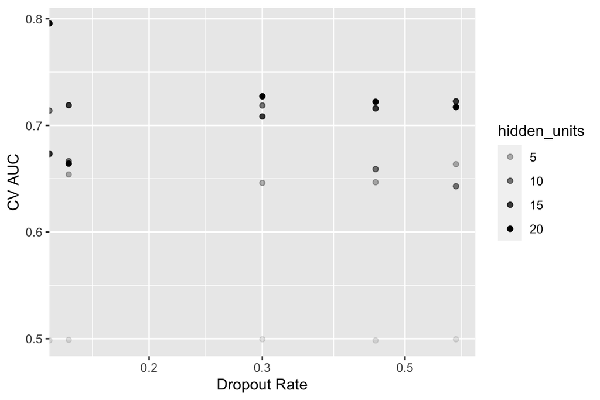

```r
# Visualize CV results:
mlp_fit %>%
  collect_metrics() %>%
  print(width = Inf) %>%
  filter(.metric == "roc_auc") %>%
  ggplot(mapping = aes(x = dropout, y = mean, alpha = hidden_units)) +
  geom_point() +
  labs(x = "Dropout Rate", y = "CV AUC") +
  scale_x_log10()
```

```r
# Show the top 5 models:
mlp_fit %>% show_best("roc_auc")
```

```
# A tibble: 5 × 8
  hidden_units dropout .metric .estimator  mean     n std_err .config
         <int>   <dbl> <chr>   <chr>      <dbl> <int>   <dbl> <chr>
1           20    0    roc_auc binary     0.796     5 0.00559 Preprocessor1_Mod…
2           20    0.3  roc_auc binary     0.727     5 0.0579  Preprocessor1_Mod…
3           15    0.6  roc_auc binary     0.723     5 0.0564  Preprocessor1_Mod…
4           20    0.45 roc_auc binary     0.722     5 0.0566  Preprocessor1_Mod…
5           15    0.15 roc_auc binary     0.719     5 0.0560  Preprocessor1_Mod…
```

```r
# Select the best model:
best_mlp <- mlp_fit %>%
  select_best("roc_auc")
best_mlp
```

```
# A tibble: 1 × 3
  hidden_units dropout .config
         <int>   <dbl> <chr>
1           20       0 Preprocessor1_Model05
```

```r
# Finalize the model:
# Final workflow:
final_wf_mlp <- mlp_wf %>%
  finalize_workflow(best_mlp)
final_wf_mlp
```

```
══ Workflow ════════════════════════════════════════════════════════════════════
Preprocessor: Recipe
Model: mlp()

── Preprocessor ────────────────────────────────────────────────────────────────
16 Recipe Steps

• step_impute_mean()
• step_impute_mean()
• step_impute_mean()
• step_impute_mean()
• step_impute_mean()
• step_impute_mean()
• step_impute_mean()
• step_impute_mean()
• step_impute_mean()
• step_impute_mean()
• ...
• and 6 more steps.

── Model ───────────────────────────────────────────────────────────────────────
Single Layer Neural Network Model Specification (classification)

Main Arguments:
  hidden_units = 20
  dropout = 0
  epochs = 50

Engine-Specific Arguments:
  verbose = 0

Computational engine: keras
```

```r
# Fit the whole training set and predict the test cases
final_fit_mlp <- final_wf_mlp %>%
  last_fit(data_split)
final_fit_mlp
```

```
# Resampling results
# Manual resampling
# A tibble: 1 × 6
  splits                id               .metrics .notes   .predict…¹ .workflow
  <list>                <chr>            <list>   <list>   <list>     <list>
1 <split [26575/26575]> train/test split <tibble> <tibble> <tibble>   <workflow>
# … with abbreviated variable name ¹.predictions
```

```r
# Test metrics
final_fit_mlp %>% collect_metrics()
```

```
# A tibble: 2 × 4
  .metric  .estimator .estimate .config
  <chr>    <chr>          <dbl> <chr>
1 accuracy binary         0.896 Preprocessor1_Model1
2 roc_auc  binary         0.802 Preprocessor1_Model1
```

### 1.3 Compare model classification performance on the test set. Report both the area under ROC curve and accuracy for each model.

```r
# Logistic regression with elastic net regularization:
final_fit %>% collect_metrics()
```

```
# A tibble: 2 × 4
  .metric  .estimator .estimate .config
  <chr>    <chr>          <dbl> <chr>
1 accuracy binary         0.908 Preprocessor1_Model1
2 roc_auc  binary         0.807 Preprocessor1_Model1
```

```r
# Random forest:
final_fit_rf %>% collect_metrics()
```

```
# A tibble: 2 × 4
  .metric  .estimator .estimate .config
  <chr>    <chr>          <dbl> <chr>
1 accuracy binary         0.924 Preprocessor1_Model1
2 roc_auc  binary         0.881 Preprocessor1_Model1
```

```r
# XGBoost:
final_fit_gb %>% collect_metrics()
```

```
# A tibble: 2 × 4
  .metric  .estimator .estimate .config
  <chr>    <chr>          <dbl> <chr>
1 accuracy binary         0.932 Preprocessor1_Model1
2 roc_auc  binary         0.891 Preprocessor1_Model1
```

```r
# MLP:
final_fit_mlp %>% collect_metrics()
```

```
# A tibble: 2 × 4
  .metric  .estimator .estimate .config
  <chr>    <chr>          <dbl> <chr>
1 accuracy binary         0.896 Preprocessor1_Model1
2 roc_auc  binary         0.802 Preprocessor1_Model1
```

The accuracy and area under the ROC curve of the logistic regression with elastic net regulation model are 0.9076576 and 0.8068327, respectively.

The accuracy and area under the ROC curve of the random forest model are 0.9239511 and 0.8808497, respectively.

The accuracy and area under the ROC curve of the XGBoost model are 0.9315522 and 0.8909976, respectively.

I was not able to finish running the SVM with RBF Kernel model as it was taking hours.

Overall, among the models that were run, the XGBoost model showed the best model classification performance on the test set, as indicated by both its accuracy and its area under the ROC curve.